# Pricing Exchange Traded Funds in laboratory markets

J. Duffy (UC Irvine), J.P. Rabanal (Monash U), O. Rud (RMIT University),

## Outline

- Motivation
- Research question
- Design
- Preliminary results
- Ongoing and future work

## Motivation

- Exchange-Traded Funds (ETF) under management are $4.3 trillion in Sep.17 (Lettau and Madhavan, 2018)
- An ETF seeks to track the performance of a specific index.
- An ongoing debate about the benefits of ETF.
- Experiments can contribute to the discussion.

## Research question

How do ETFs affect

- price discovery
- trading volume
- free riding
- diversification

## Experimental Design

- single asset market of Smith, Suchanek and Williams (1988, hereafter SSW)
- we extend SSW to multiple assets (two) jointly with or without an ETF.
- 2 x 2 design, where another factor is correlation across assets $\rho\in (-1,0)$

## Experimental Design

- A, B and ETF$\rightarrow C$ , where $C= A + B$ (equal weights).
- T = 15 trading periods
- dividend streams per period,
  - A pays 1 or -1
  - Under $\rho=-1$, B pays the opposite of A in all periods. Starting from t=8, pays plus 1.
- termination value of 10 for A and B.

## Experimental Design

- Each session: 9 players, 2 set of markets
- One market is randomly paid (avoid wealth effects)
- One call market per asset
- Endowments of (A, B, C, cash) according to player type

[output not shown]

## Experimental Design

- UI in oTree (developed by the authors)

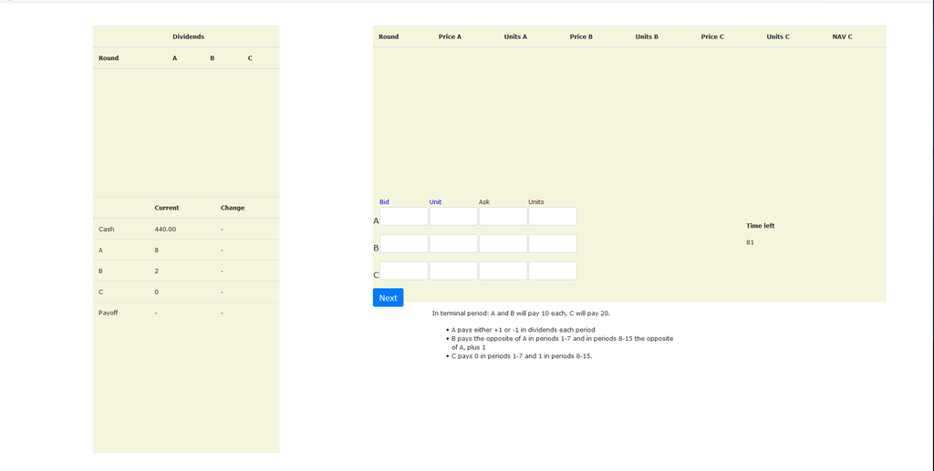

- Subjects: students from UC Irvine

## Results [one session 2N]

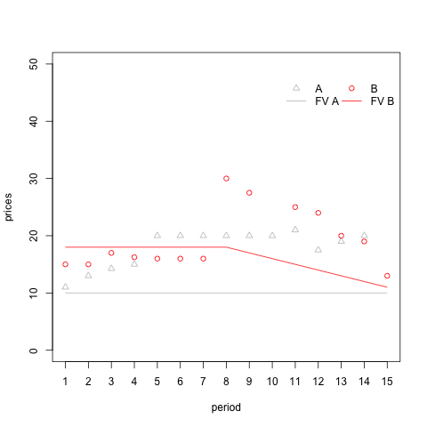

## Results [one session 2N]

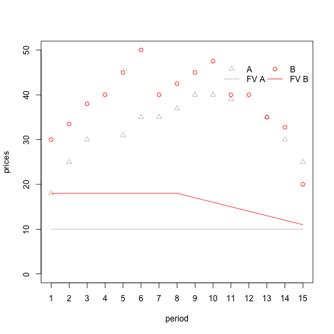

## Results [one session 3N]

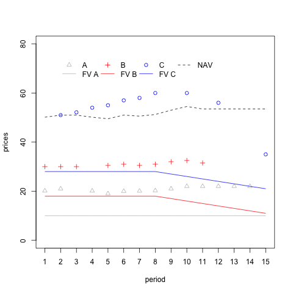

## Results [one session 3N]

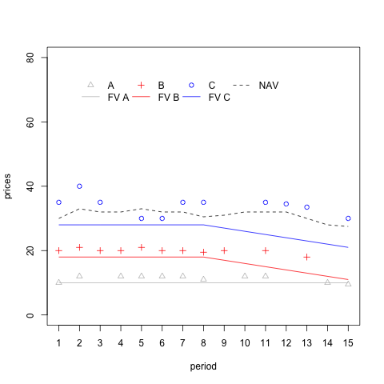